# Análisis exploratorio de datos

#### Probabilidad 2 Grupo: 9043

## Probabilidad

Se realiza un experimento donde se conoce qué distribución o ley de probabilidad sigue.

Ejemplo: Tirar un dado equilibrado (probabilidad clásica, eventos equiprobables).

Es decir, conocemos la distribución asociada a la variable aleatoria $X$, donde $X$ denota el resultado de tirar un dado.

Una vez que conocemos la distribución asociada al experimento aleatorio, podemos generar números (pseudo)aleatorios que sigan dicha distribución.

Por ejemplo:

```python
print(dice_data)
```

```
[3 4 5 4 2 1 3 2 1 4 2 2 2 5 5]
```

¿Qué pasa si consideramos el problema inverso?

Es decir, si partimos de un conjunto de datos, ¿qué podemos hacer para saber, al menos intuitivamente, qué distribución siguen?

Por ejemplo, consideremos los siguientes datos medidos en algún experimento:

```python
print(unknow_data)
```

```
[ 3.17  7.14  2.52  4.79  7.28  4.16  3.04  4.97  3.53  5.55  2.3   5.87
  5.23  5.5   5.11  3.99  6.13  4.21  6.46  2.75  4.44  5.55  3.86  5.86
  6.83  6.39  5.08  6.88  5.37  6.2   3.2   3.3   4.71  5.48  0.67  2.03
  5.97  4.91  4.82  2.59  3.05  2.96  3.38  5.28  3.56  3.62  7.09  5.36
  0.27  5.39  0.02  7.38  5.26  3.39  5.18 -1.44  1.44  2.67  2.58  4.35
  6.88  2.89  9.12  2.33  4.8   7.95  4.9   4.52  1.5   3.24  4.64  2.12
  2.51  6.05  7.9   6.4   3.16  4.32  6.11  7.16  4.14  6.9   1.79  4.74
  3.72  4.13  2.91  5.93  3.95  4.09  5.02  2.59  1.21  2.59  1.56  2.47
  3.37  5.76  4.49  3.58]
```

¿Qué distribución o modelo siguen?

## Suposiciones

1. Sup. existe una variable aleatoria $X$ que genera los datos  
Es decir, la variable aleatoria toma los valores observados con alguna probabilidad.

2. Entonces podemos considerar que los $n=100$ valores observados son la realización de $n$ variables aleatorias independientes e indénticamente distribuidas $X_1,...,X_n$.

3. Existe un modelo (una distribución) tal que $\forall i \in \{1,...,n \}$, $X_i \sim F$.

Obs: a priori no conocemos la forma de la distribución $F$.

Nota: Al conjunto de datos observado de un experimento aleatorio se le llama muestra aletoria y se denota como $\{x_1, \dots , x_n \}$.

Hay dos formas de atacar este problema:

- Numérica
- Localización (medidas de tendencia central)

- Media $\mu = \mathbb{E}(X)$ : centro de masa.  
- Moda $arg sup_{x \in \mathcal{X}} f(x)$ : máximo global.  
- Mediana $m = inf \left\{x \in \mathbb{R}: F(x) \geq \frac{1}{2} \right\}$ : punto que divide a la densidad en dos partes iguales.

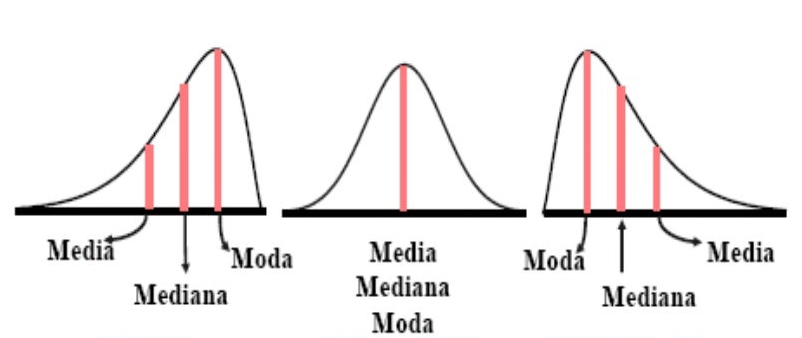

- Numérica
- Dispersión.

- Varianza $\mathbb{V}ar = \mathbb{E}[(X- \mathbb{E}(X))^2]$ : qué tanto se dispersan/alejan los valores de la media.
- Rango Intercuartil
$$IQR = inf \left\{x \in \mathbb{R}: F(x)\geq \frac{3}{4} \right\} - inf \left\{ x \in \mathbb{R}: F(x) \geq \frac{1}{4} \right\}$$
: mide la longitud del intervalo más central que contiene el $50\%$ de la distribución.

- Numérica
- Simetría.
- Comportamiento de las colas.
- Gráfica
- Histograma.
- Boxplot.

## Ejemplo

Sea $T \sim \exp (\lambda)$.

Es decir $f_T (t) = \lambda e^{-\lambda t}$, $sop(T) = \mathbb{R}^{+} \cup \{0\}$ y $\lambda \in \mathbb{R}^{+}$

Entonces

Media:  
\begin{align*} \mu = \mathbb{E}(X) &= \int _{\mathbb{R}} t f_T(t)dt \\ &= \int _{0} ^{\infty} t f_T(t)dt \\ &= \int _{0} ^{\infty} t \lambda e^{-\lambda t} dt \\ &= \frac{1}{\lambda} \end{align*}

Moda:  
\begin{align*} \bar{m} &= arg sup_{x \in \mathcal{X}} f(x)\\ &= 0 \end{align*}

Mediana:  
\begin{align*} m &= inf \left\{x \in \mathbb{R}: F(x) \geq \frac{1}{2} \right\}\\ &= \frac{\ln 2}{\lambda} \end{align*}

## Tarea moral: Calcula $\mathbb{V}ar(X)$ e $IQR$

## Regresando a los datos que teníamos...

Como no conocemos la distribución que genera los datos, tenemos que definir cantidades muestrales (es decir, de la muestra).

- Muestra ordenada $$\min\{x_1,\dots,x_n\}= x_{(1)} \leq x_{(2)} \leq \dots \leq x_{(n)} = \max \{x_1,\dots, x_n \}$$
- Media muestral $$\bar{x} := \frac{1}{n} \sum _{i=1} ^{n} x_i$$
- Mediana muestral $$ M = \begin{cases} x_{\left(\frac{n+1}{2}\right)} \hspace{0.2 cm} \mbox{ si $n$ es impar} \\ \\ \frac{x_{\left(\frac{n}{2}\right)} \hspace{0.2 cm} + \hspace{0.2 cm} x_{\left(\frac{n}{2}+1 \right)}}{2} \hspace{0.2 cm} \mbox{ si $n$ es par } \end{cases}$$

- Varianza muestral $$\hat{\sigma}^2 = \frac{1}{n} \sum _{i=1}^{n} (x_i - \bar{x})^2$$
- El primer cuartil $Q_1$ es la mediana de $$x_{(1)}, \dots, M$$
- El segundo cuartil $Q_2 = M$ coincide con la mediana de toda la muestra.
- El tercer cuartil $Q_3$ es la mediana de $$M, \dots, x_{(n)}$$
- Rango intercuartil: $IQR = Q_3 - Q_1$
- Un outlier es una observación (es decir, algún valor $x_i$) que está fuera del intervalo $\left[Q_1 - \frac{3}{2}IQR, Q_3 + \frac{3}{2}IQR \right]$

Malas noticias...

Esto está fuera del alcance del curso de probabilidad 2: tendrán que esperar hasta estadística 1 y estadística 2 para resolver el problema planteado de manera satisfactoria.